# Plotting Designs from FielDHub Package

Jens Harbers

2025-01-30

# Usage of the package

Unlike the usual presentation approach, I deliberately inserted the output of the ‘FielDHub’ functions into the vignette and executed each function individually. This allows interested users to directly adopt the code.

For ‘agricolaeplotr’, it is necessary to plot each location individually, while ‘FielDHub’ offers the option to create multiple locations simultaneously.

To illustrate the similarity of both plots, I have juxtaposed both versions.

## Load the package

```r
library("agricolaeplotr")
library("FielDHub")
library("ggplot2")
```

# Example 1: Randomized Complete Block Design (RCBD)

```r
example("RCBD")
```

```
##
## RCBD> # Example 1: Generates a RCBD design with 3 blocks and 20 treatments across 3 locations.
## RCBD> rcbd1 <- RCBD(t = LETTERS[1:20], reps = 5, l = 3,
## RCBD+               plotNumber = c(101,1001, 2001),
## RCBD+               continuous = TRUE,
## RCBD+               planter = "serpentine",
## RCBD+               seed = 1020,
## RCBD+               locationNames = c("FARGO", "MINOT", "CASSELTON"))
##
## RCBD> rcbd1$infoDesign
## $blocks
## [1] 5
##
## $number.of.treatments
## [1] 20
##
## $treatments
##  [1] "A" "B" "C" "D" "E" "F" "G" "H" "I" "J" "K" "L" "M" "N" "O" "P" "Q" "R" "S"
## [20] "T"
##
## $locations
## [1] 3
##
## $plotNumber
##  [1]  101  201  301  401  501 1001 1101 1201 1301 1401 2001 2101 2201 2301 2401
##
## $locationNames
## [1] "FARGO"     "MINOT"     "CASSELTON"
##
## $seed
## [1] 1020
##
## $id_design
## [1] 2
##
##
## RCBD> rcbd1$layoutRandom
## $Loc_FARGO
##      Block --Treatments--
## [1,] "1"   "P R L T E A J O M C K F I Q G D S H N B"
```

[output cut: 154 more lines]

```
## [2,]   204   203   202   201
## [3,]   315   316   317   318
## [4,]   404   403   402   401
## [5,]   515   516   517   518
## [6,]   604   603   602   601
##
##
## RCBD> head(rcbd2$fieldBook)
##   ID LOCATION PLOT REP TREATMENT
## 1  1   IBAGUE  101   1      ND-3
## 2  2   IBAGUE  102   1      ND-5
## 3  3   IBAGUE  103   1     ND-10
## 4  4   IBAGUE  104   1     ND-13
## 5  5   IBAGUE  105   1      ND-6
## 6  6   IBAGUE  106   1     ND-14
```

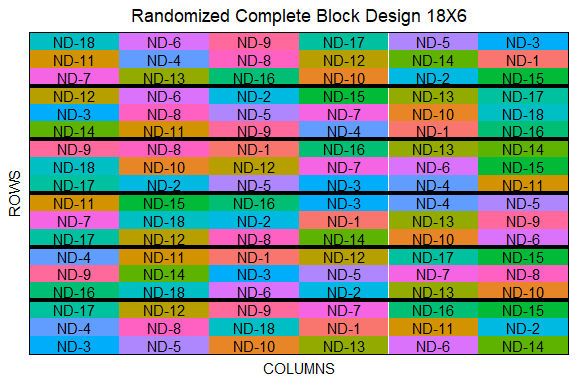

```r
plt <- plot(rcbd2)
```

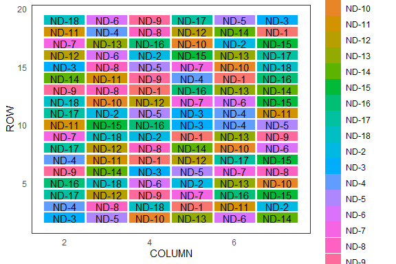

```r
p <- full_control_positions(plt$field_book, "COLUMN", "ROW", factor_name = "TREATMENT", label = "TREATMENT")
p
```

# Example 2: Latin Square Design

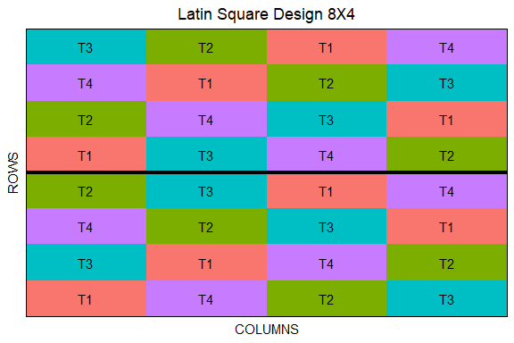

```r
latinSq1 <- latin_square(t = 4, reps = 2, plotNumber = 101, planter = "cartesian", seed = 1980)
plt <- plot(latinSq1)
```

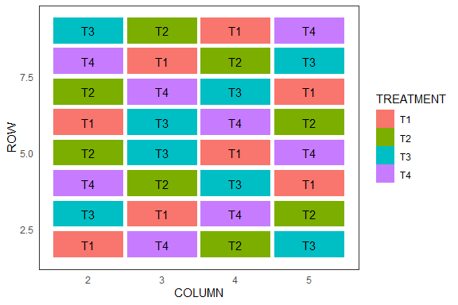

```r
p <- full_control_positions(plt$field_book, "COLUMN", "ROW", factor_name = "TREATMENT", label = "TREATMENT")
p
```

# Example 3: Full Factorial Design

```r
example("full_factorial")
```

```
##
## fll_fc> # Example 1: Generates a full factorial with 3 factors each with 2 levels.
## fll_fc> # This in an RCBD arrangement with 3 reps.
## fll_fc> fullFact1 <- full_factorial(setfactors = c(2,2,2), reps = 3, l = 1, type = 2,
## fll_fc+                             plotNumber = 101,
## fll_fc+                             continuous = TRUE,
## fll_fc+                             planter = "serpentine",
## fll_fc+                             seed = 325,
## fll_fc+                             locationNames = "FARGO")
##
## fll_fc> fullFact1$infoDesign
## $factors
## [1] "A" "B" "C"
##
## $levels
## [1] 0 1 0 1 0 1
##
## $runs
## [1] 8
##
## $all_treatments
##   A B C
## 1 0 0 0
## 2 1 0 0
## 3 0 1 0
## 4 1 1 0
## 5 0 0 1
## 6 1 0 1
## 7 0 1 1
## 8 1 1 1
##
## $reps
## [1] 3
##
## $locations
## [1] 1
##
## $location_names
## [1] "FARGO"
##
```

[output cut: 99 more lines]

```
## [1] 4
##
##
## fll_fc> head(fullFact2$fieldBook,10)
##    ID LOCATION PLOT REP FACTOR_A FACTOR_B FACTOR_C TRT_COMB
## 1   1     Loc1  101   1       a0       b1       c0 a0*b1*c0
## 2   2     Loc1  102   1       a1       b0       c1 a1*b0*c1
## 3   3     Loc1  103   1       a1       b2       c1 a1*b2*c1
## 4   4     Loc1  104   1       a0       b1       c1 a0*b1*c1
## 5   5     Loc1  105   1       a1       b0       c0 a1*b0*c0
## 6   6     Loc1  106   1       a0       b0       c1 a0*b0*c1
## 7   7     Loc1  107   1       a1       b1       c0 a1*b1*c0
## 8   8     Loc1  108   1       a0       b2       c1 a0*b2*c1
## 9   9     Loc1  109   1       a1       b1       c1 a1*b1*c1
## 10 10     Loc1  110   1       a0       b0       c0 a0*b0*c0
```

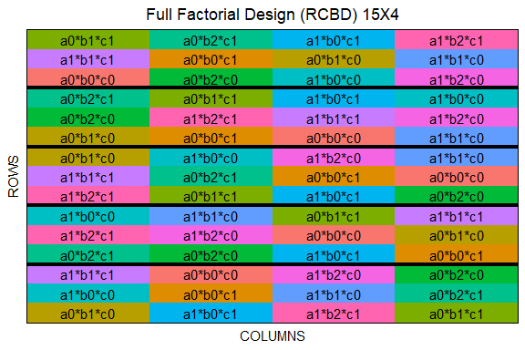

```r
plt <- plot(fullFact2, l = 1)
```

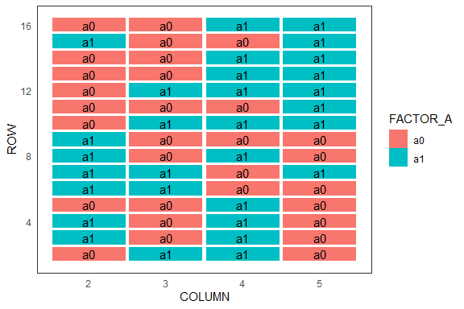

```r
p <- full_control_positions(plt$field_book[plt$field_book$LOCATION == "Loc1",], "COLUMN", "ROW", factor_name = "FACTOR_A", label = "FACTOR_A")
p
```

# Example 4: Incomplete Blocks Design

```r
example("incomplete_blocks")
```

```
##
## incmp_> # Example 1: Generates a resolvable IBD of characteristics (t,k,r) = (12,4,2).
## incmp_> # 1-resolvable IBDs
## incmp_> ibd1 <- incomplete_blocks(t = 12,
## incmp_+                           k = 4,
## incmp_+                           r = 2,
## incmp_+                           seed = 1984)
##
## incmp_> ibd1$infoDesign
## $Reps
## [1] 2
##
## $iBlocks
## [1] 3
##
## $NumberTreatments
## [1] 12
##
## $NumberLocations
## [1] 1
##
## $Locations
## [1] 1
##
## $seed
## [1] 1984
##
## $lambda
## [1] 0.5454545
##
## $id_design
## [1] 8
##
##
## incmp_> head(ibd1$fieldBook)
##   ID LOCATION PLOT REP IBLOCK UNIT ENTRY TREATMENT
## 1  1        1  101   1      1    1     8       G-8
## 2  2        1  102   1      1    2     9       G-9
## 3  3        1  103   1      1    3    12      G-12
## 4  4        1  104   1      1    4     1       G-1
```

[output cut: 45 more lines]

```
## $lambda
## [1] 1
##
## $id_design
## [1] 8
##
##
## incmp_> head(ibd2$fieldBook)
##   ID LOCATION PLOT REP IBLOCK UNIT ENTRY TREATMENT
## 1  1        1  101   1      1    1     8      TX-8
## 2  2        1  102   1      1    2    11     TX-11
## 3  3        1  103   1      1    3     2      TX-2
## 4  4        1  104   1      2    1     4      TX-4
## 5  5        1  105   1      2    2    14     TX-14
## 6  6        1  106   1      2    3    13     TX-13
```

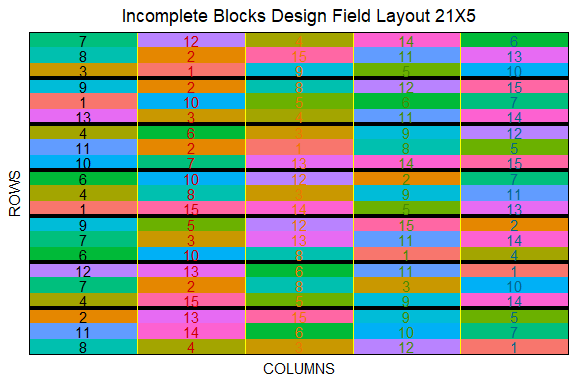

```r
plt <- plot(ibd2)
```

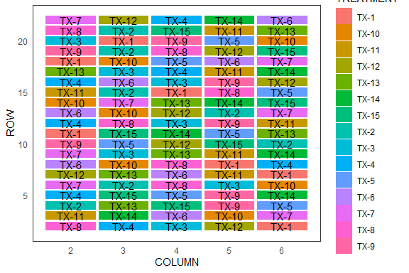

```r
p <- full_control_positions(plt$field_book, "COLUMN", "ROW", factor_name = "TREATMENT", label = "TREATMENT")
p
```

# Example 5: Diagonal Arrangement Design

```r
example("diagonal_arrangement")
```

```
##
## dgnl_r> # Example 1: Generates a spatial single diagonal arrangement design in one location
## dgnl_r> # with 270 treatments and 30 check plots for a field with dimensions 15 rows x 20 cols
## dgnl_r> # in a serpentine arrangement.
## dgnl_r> spatd <- diagonal_arrangement(
## dgnl_r+   nrows = 15,
## dgnl_r+   ncols = 20,
## dgnl_r+   lines = 270,
## dgnl_r+   checks = 4,
## dgnl_r+   plotNumber = 101,
## dgnl_r+   kindExpt = "SUDC",
## dgnl_r+   planter = "serpentine",
## dgnl_r+   seed = 1987,
## dgnl_r+   exptName = "20WRY1",
## dgnl_r+   locationNames = "MINOT"
## dgnl_r+ )
##
## dgnl_r> spatd$infoDesign
## $rows
## [1] 15
##
## $columns
## [1] 20
##
## $treatments
## [1] 270
##
## $checks
## [1] 4
##
## $entry_checks
## $entry_checks[[1]]
## [1] 1 2 3 4
##
##
## $rep_checks
## $rep_checks[[1]]
## [1] 8 7 8 7
##
##
```

[output cut: 560 more lines]

```
##
## dgnl_r> head(spatAB$fieldBook,12)
##    ID  EXPT LOCATION YEAR PLOT ROW COLUMN CHECKS ENTRY TREATMENT
## 1   1 20WRA        1 2025    1   1      1      0    79    Gen-79
## 2   2 20WRA        1 2025    2   1      2      0    62    Gen-62
## 3   3 20WRA        1 2025    3   1      3      0    78    Gen-78
## 4   4 20WRA        1 2025    4   1      4      0    22    Gen-22
## 5   5 20WRA        1 2025    5   1      5      0    87    Gen-87
## 6   6 20WRB        1 2025 1001   1      6      0   121   Gen-121
## 7   7 20WRB        1 2025 1002   1      7      0   124   Gen-124
## 8   8 20WRB        1 2025 1003   1      8      0   112   Gen-112
## 9   9 20WRB        1 2025 1004   1      9      1     1   Check-1
## 10 10 20WRB        1 2025 1005   1     10      0   128   Gen-128
## 11 11 20WRC        1 2025 2001   1     11      0   228   Gen-228
## 12 12 20WRC        1 2025 2002   1     12      0   261   Gen-261
```

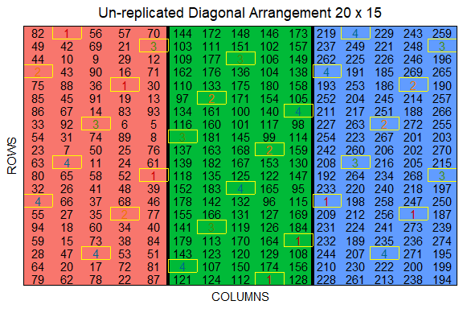

```r
plt <- plot(spatAB)
```

[figure not shown]

```r
p <- full_control_positions(plt$field_book, "COLUMN", "ROW", factor_name = "TREATMENT", label = "TREATMENT")
p
```

# Example 6: Augmented Randomized Complete Block Design (ARCBD)

```r
example("RCBD_augmented")
```

```
##
## RCBD_g> # Example 1: Generates an ARCBD with 6 blocks, 3 checks for each, and 50 treatments
## RCBD_g> # in two locations.
## RCBD_g> ARCBD1 <- RCBD_augmented(lines = 50, checks = 3, b = 6, l = 2,
## RCBD_g+                          planter = "cartesian",
## RCBD_g+                          plotNumber = c(1,1001),
## RCBD_g+                          seed = 23,
## RCBD_g+                          locationNames = c("FARGO", "MINOT"))
##
## RCBD_g> ARCBD1$infoDesign
## $rows
## [1] 6
##
## $columns
## [1] 12
##
## $rows_within_blocks
## [1] 1
##
## $columns_within_blocks
## [1] 12
##
## $treatments
## [1] 50
##
## $checks
## [1] 3
##
## $blocks
## [1] 6
##
## $plots_per_block
## [1] 12 12 12 12 12  8
##
## $locations
## [1] 2
##
## $fillers
## [1] 4
##
```

[output cut: 251 more lines]

```
##
## RCBD_g> head(ARCBD2$fieldBook, 12)
##    ID  EXPT LOCATION YEAR PLOT ROW COLUMN CHECKS BLOCK ENTRY TREATMENT
## 1   1 Expt1        A 2025  101   1      1      0     1   345      G345
## 2   2 Expt1        A 2025  102   1      2      0     1   130      G130
## 3   3 Expt1        A 2025  103   1      3      1     1     4       CH4
## 4   4 Expt1        A 2025  104   1      4      0     1   162      G162
## 5   5 Expt1        A 2025  105   1      5      1     1     1       CH1
## 6   6 Expt1        A 2025  106   1      6      0     1   123      G123
## 7   7 Expt1        A 2025  107   1      7      1     1     2       CH2
## 8   8 Expt1        A 2025  108   1      8      0     1    39       G39
## 9   9 Expt1        A 2025  109   1      9      0     1     9        G9
## 10 10 Expt1        A 2025  110   1     10      0     1   302      G302
## 11 11 Expt1        A 2025  111   1     11      0     1   210      G210
## 12 12 Expt1        A 2025  112   1     12      0     1   352      G352
```

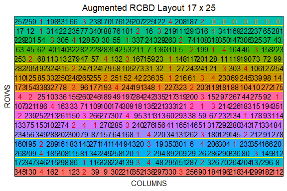

```r
plt <- plot(ARCBD2)
```

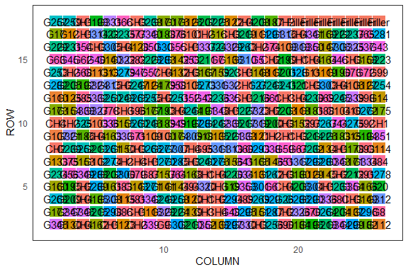

```r
p <- full_control_positions(plt$field_book[plt$field_book$LOCATION == "A",], "COLUMN", "ROW", factor_name = "TREATMENT", label = "TREATMENT") + guides(fill = "none")
p
```

# Example 7: Rectangular Lattice Design

```r
example("rectangular_lattice")
```

```
##
## rctng_> # Example 1: Generates a rectangular lattice design with 6 full blocks, 4 units per IBlock (k)
## rctng_> # and 20 treatments in one location.
## rctng_> rectangularLattice1 <- rectangular_lattice(t = 20, k = 4, r = 6, l = 1,
## rctng_+                                            plotNumber = 101,
## rctng_+                                            locationNames = "FARGO",
## rctng_+                                            seed = 126)
##
## rctng_> rectangularLattice1$infoDesign
## $Reps
## [1] 6
##
## $iBlocks
## [1] 5
##
## $NumberTreatments
## [1] 20
##
## $NumberLocations
## [1] 1
##
## $Locations
## [1] "FARGO"
##
## $seed
## [1] 126
##
## $lambda
## [1] 0.9473684
##
## $id_design
## [1] 11
##
##
## rctng_> head(rectangularLattice1$fieldBook,12)
##    ID LOCATION PLOT REP IBLOCK UNIT ENTRY TREATMENT
## 1   1    FARGO  101   1      1    1    15      G-15
## 2   2    FARGO  102   1      1    2    13      G-13
## 3   3    FARGO  103   1      1    3    12      G-12
## 4   4    FARGO  104   1      1    4    16      G-16
```

[output cut: 58 more lines]

```
##
## rctng_> head(rectangularLattice2$fieldBook,12)
##    ID LOCATION PLOT REP IBLOCK UNIT ENTRY TREATMENT
## 1   1     LOC1 1001   1      1    1     8      ND-8
## 2   2     LOC1 1002   1      1    2    35     ND-35
## 3   3     LOC1 1003   1      1    3    52     ND-52
## 4   4     LOC1 1004   1      1    4    29     ND-29
## 5   5     LOC1 1005   1      1    5    41     ND-41
## 6   6     LOC1 1006   1      1    6    22     ND-22
## 7   7     LOC1 1007   1      1    7    10     ND-10
## 8   8     LOC1 1008   1      2    1    45     ND-45
## 9   9     LOC1 1009   1      2    2    11     ND-11
## 10 10     LOC1 1010   1      2    3     6      ND-6
## 11 11     LOC1 1011   1      2    4    25     ND-25
## 12 12     LOC1 1012   1      2    5    34     ND-34
```

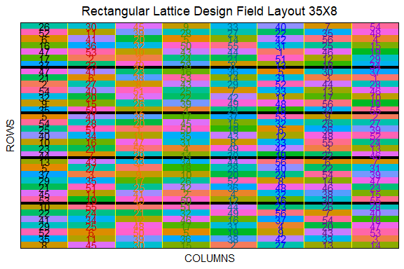

```r
plt <- plot(rectangularLattice2)
```

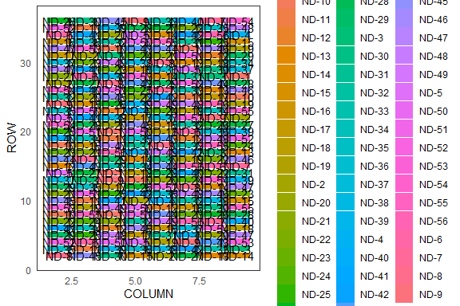

```r
p <- full_control_positions(plt$field_book[plt$field_book$LOCATION == "LOC1",], "COLUMN", "ROW", factor_name = "TREATMENT", label = "TREATMENT")
p
```

# Example 8: Strip Plot Design

```r
example("strip_plot")
```

```
##
## strp_p> # Example 1: Generates a strip plot design with 5 vertical strips and 4 horizontal strips,
## strp_p> # with 3 reps in one location.
## strp_p> H <- paste("H", 1:4, sep = "")
##
## strp_p> V <- paste("V", 1:5, sep = "")
##
## strp_p> strip1 <- strip_plot(Hplots = H,
## strp_p+                      Vplots = V,
## strp_p+                      b = 3,
## strp_p+                      l = 1,
## strp_p+                      plotNumber = 101,
## strp_p+                      planter = "serpentine",
## strp_p+                      locationNames = "A",
## strp_p+                      seed = 333)
##
## strp_p> strip1$infoDesign
## $Hplots
## [1] 4
##
## $Vplots
## [1] 5
##
## $blocks
## [1] 3
##
## $numberLocations
## [1] 1
##
## $nameLocations
## [1] "A"
##
## $seed
## [1] 333
##
## $id_design
## [1] 7
##
##
## strp_p> strip1$stripsBlockLoc
```

[output cut: 416 more lines]

```
##
## strp_p> head(strip2$fieldBook,12)
##    ID LOCATION PLOT REP HSTRIP VSTRIP TRT_COMB
## 1   1        A  101   1      E      D      E|D
## 2   2        A  102   1      E      B      E|B
## 3   3        A  103   1      E      C      E|C
## 4   4        A  104   1      E      A      E|A
## 5   5        A  105   1      B      D      B|D
## 6   6        A  106   1      B      B      B|B
## 7   7        A  107   1      B      C      B|C
## 8   8        A  108   1      B      A      B|A
## 9   9        A  109   1      C      D      C|D
## 10 10        A  110   1      C      B      C|B
## 11 11        A  111   1      C      C      C|C
## 12 12        A  112   1      C      A      C|A
```

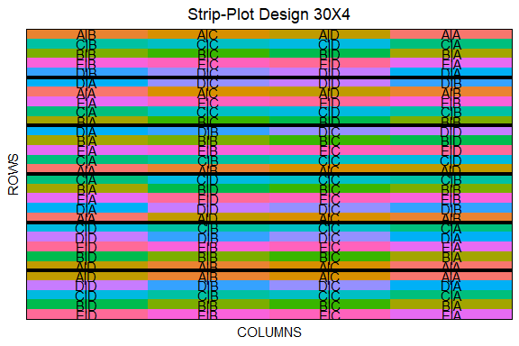

```r
plt <- plot(strip2)
```

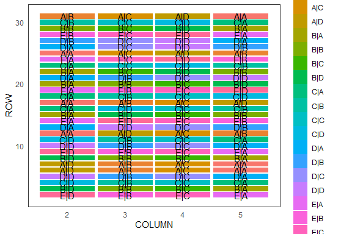

```r
p <- full_control_positions(plt$field_book[plt$field_book$LOCATION == "A",], "COLUMN", "ROW", factor_name = "TRT_COMB", label = "TRT_COMB")
p
```

# Example 9: Square Lattice Design

```r
example("square_lattice")
```

```
##
## sqr_lt> # Example 1: Generates a square lattice design with 5 full blocks, 8 units per IBlock,
## sqr_lt> # 8 IBlocks for a square number of treatmens of 64 in two locations.
## sqr_lt> squareLattice1 <- square_lattice(t = 64, k = 8, r = 5, l = 2,
## sqr_lt+                                  plotNumber = c(1001, 2001),
## sqr_lt+                                  locationNames = c("FARGO", "MINOT"),
## sqr_lt+                                  seed = 1986)
##
## sqr_lt> squareLattice1$infoDesign
## $Reps
## [1] 5
##
## $IBlocks
## [1] 8
##
## $NumberTreatments
## [1] 64
##
## $NumberLocations
## [1] 2
##
## $Locations
## [1] "FARGO" "MINOT"
##
## $seed
## [1] 1986
##
## $lambda
## [1] 0.5555556
##
## $id_design
## [1] 10
##
##
## sqr_lt> head(squareLattice1$fieldBook,12)
##    ID LOCATION PLOT REP IBLOCK UNIT ENTRY TREATMENT
## 1   1    FARGO 1001   1      1    1    34      G-34
## 2   2    FARGO 1002   1      1    2    58      G-58
## 3   3    FARGO 1003   1      1    3    10      G-10
## 4   4    FARGO 1004   1      1    4    18      G-18
```

[output cut: 58 more lines]

```
##
## sqr_lt> head(squareLattice2$fieldBook,12)
##    ID  LOCATION PLOT REP IBLOCK UNIT ENTRY TREATMENT
## 1   1 CASSELTON 1001   1      1    1    39       G39
## 2   2 CASSELTON 1002   1      1    2    26       G26
## 3   3 CASSELTON 1003   1      1    3    13       G13
## 4   4 CASSELTON 1004   1      1    4    49       G49
## 5   5 CASSELTON 1005   1      1    5    16       G16
## 6   6 CASSELTON 1006   1      1    6     3        G3
## 7   7 CASSELTON 1007   1      1    7    29       G29
## 8   8 CASSELTON 1008   1      2    1    14       G14
## 9   9 CASSELTON 1009   1      2    2    27       G27
## 10 10 CASSELTON 1010   1      2    3     4        G4
## 11 11 CASSELTON 1011   1      2    4    30       G30
## 12 12 CASSELTON 1012   1      2    5    40       G40
```

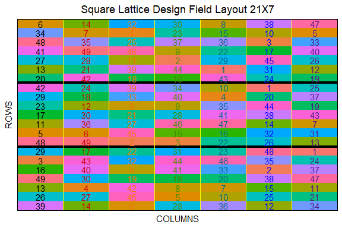

```r
plt <- plot(squareLattice2)
```

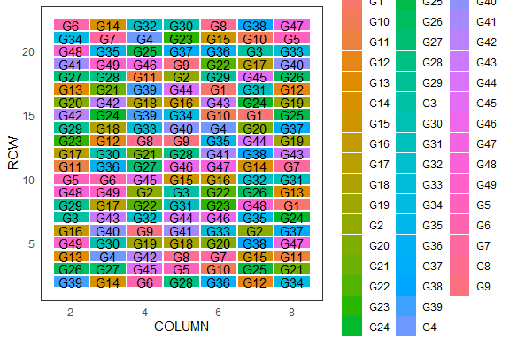

```r
p <- full_control_positions(plt$field_book[plt$field_book$LOCATION == "CASSELTON",], "COLUMN", "ROW", factor_name = "TREATMENT", label = "TREATMENT")
p
```

# Example 10: Split Plot Design

```r
example("split_plot")
```

```
##
## splt_p> # Example 1: Generates a split plot design SPD with 4 whole plots, 2 sub plots per whole plot,
## splt_p> # and 4 reps in an RCBD arrangement. This in for a single location.
## splt_p> SPDExample1 <- split_plot(wp = 4, sp = 2, reps = 5, l = 1,
## splt_p+                           plotNumber = 101,
## splt_p+                           seed = 14,
## splt_p+                           type = 2,
## splt_p+                           locationNames = "FARGO")
##
## splt_p> SPDExample1$infoDesign
## $WholePlots
## [1] 1 2 3 4
##
## $SubPlots
## [1] 1 2
```

[output cut: 325 more lines]

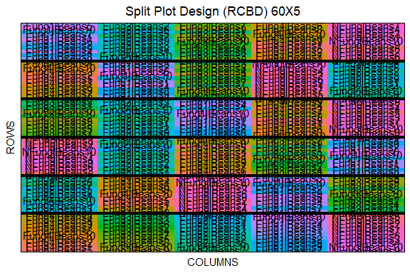

```r
plt <- plot(SPDExample2)
```

[figure not shown]

```r
p <- full_control_positions(plt$field_book[plt$field_book$LOCATION == "A",], "COLUMN", "ROW", factor_name = "TRT_COMB", label = "TRT_COMB")
p
```

# Example 11: Split-Split Plot Design

```r
example("split_split_plot")
```

```
##
## splt__> # Example 1: Generates a split split plot design SSPD with 5 whole plots, 2 sub-plots,
## splt__> # 3 sub-sub plots, and 3 reps in an RCBD arrangement. This is for one location.
## splt__> SSPD1 <- split_split_plot(wp = 4, sp = 2, ssp = 3, reps = 5, l = 1,
## splt__+                           plotNumber = 101,
## splt__+                           seed = 23,
## splt__+                           type = 2,
## splt__+                           locationNames = "FARGO")
##
## splt__> SSPD1$infoDesign
## $Whole.Plots
## [1] 1 2 3 4
##
## $Sub.Plots
## [1] 1 2
##
## $Sub.Sub.Plots
## [1] 1 2 3
##
## $Locations
## [1] 1
##
## $typeDesign
## [1] "RCBD"
##
## $seed
## [1] 23
##
## $id_design
## [1] 6
##
##
## splt__> head(SSPD1$fieldBook,12)
##    ID LOCATION PLOT REP WHOLE_PLOT SUB_PLOT SUB_SUB_PLOT TRT_COMB
## 1   1    FARGO  101   1          1        2            2    1|2|2
## 2   2    FARGO  101   1          1        2            1    1|2|1
## 3   3    FARGO  101   1          1        2            3    1|2|3
## 4   4    FARGO  101   1          1        1            2    1|1|2
## 5   5    FARGO  101   1          1        1            1    1|1|1
## 6   6    FARGO  101   1          1        1            3    1|1|3
```

[output cut: 64 more lines]

```
##
## splt__> head(SSPD2$fieldBook,12)
##    ID LOCATION PLOT REP WHOLE_PLOT SUB_PLOT SUB_SUB_PLOT             TRT_COMB
## 1   1        A  101   1     IRR_NO    Fung3       Beans3  IRR_NO|Fung3|Beans3
## 2   2        A  101   1     IRR_NO    Fung3       Beans9  IRR_NO|Fung3|Beans9
## 3   3        A  101   1     IRR_NO    Fung3      Beans10 IRR_NO|Fung3|Beans10
## 4   4        A  101   1     IRR_NO    Fung3       Beans7  IRR_NO|Fung3|Beans7
## 5   5        A  101   1     IRR_NO    Fung3       Beans8  IRR_NO|Fung3|Beans8
## 6   6        A  101   1     IRR_NO    Fung3       Beans5  IRR_NO|Fung3|Beans5
## 7   7        A  101   1     IRR_NO    Fung3       Beans2  IRR_NO|Fung3|Beans2
## 8   8        A  101   1     IRR_NO    Fung3       Beans6  IRR_NO|Fung3|Beans6
## 9   9        A  101   1     IRR_NO    Fung3       Beans4  IRR_NO|Fung3|Beans4
## 10 10        A  101   1     IRR_NO    Fung3       Beans1  IRR_NO|Fung3|Beans1
## 11 11        A  101   1     IRR_NO    Fung1       Beans9  IRR_NO|Fung1|Beans9
## 12 12        A  101   1     IRR_NO    Fung1       Beans2  IRR_NO|Fung1|Beans2
```

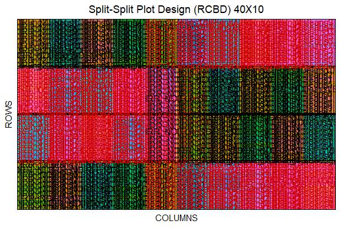

```r
plt <- plot(SSPD2)
```

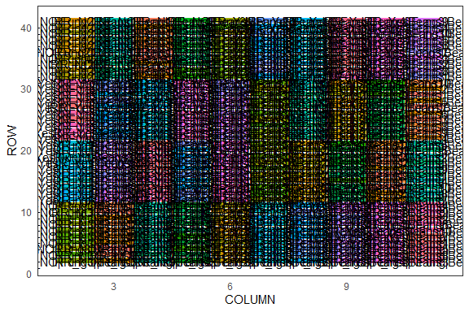

```r
p <- full_control_positions(plt$field_book[plt$field_book$LOCATION == "A",], "COLUMN", "ROW", factor_name = "TRT_COMB", label = "TRT_COMB") + guides(fill = "none")
p
```

# Example 12: Completely Randomized Design (CRD)

```r
example("CRD")
```

```
##
## CRD> # Example 1: Generates a CRD design with 10 treatments and 5 reps each.
## CRD> crd1 <- CRD(
## CRD+   t = 10,
## CRD+   reps = 5,
## CRD+   plotNumber = 101,
## CRD+   seed = 1987,
## CRD+   locationName = "Fargo"
## CRD+ )
##
## CRD> crd1$infoDesign
## $numberofTreatments
## [1] 10
##
## $treatments
##  [1] "T1"  "T2"  "T3"  "T4"  "T5"  "T6"  "T7"  "T8"  "T9"  "T10"
##
## $Reps
## [1] 5
##
## $locationName
## [1] "Fargo"
##
## $seed
## [1] 1987
##
## $id_design
## [1] 1
##
##
## CRD> head(crd1$fieldBook, 10)
##    ID LOCATION PLOT REP TREATMENT
## 1   1    Fargo  101   1       T10
## 2   2    Fargo  102   4        T1
## 3   3    Fargo  103   3        T3
## 4   4    Fargo  104   3        T9
## 5   5    Fargo  105   4        T3
## 6   6    Fargo  106   5        T3
## 7   7    Fargo  107   1        T2
## 8   8    Fargo  108   3        T4
```

[output cut: 91 more lines]

```
## [1] 1
##
##
## CRD> head(crd3$fieldBook, 10)
##    ID LOCATION PLOT REP TREATMENT
## 1   1     Cali 2001   4      ND-3
## 2   2     Cali 2002   1      ND-7
## 3   3     Cali 2003   2      ND-2
## 4   4     Cali 2004   3      ND-8
## 5   5     Cali 2005   3      ND-2
## 6   6     Cali 2006   1     ND-10
## 7   7     Cali 2007   3      ND-7
## 8   8     Cali 2008   4      ND-9
## 9   9     Cali 2009   3      ND-4
## 10 10     Cali 2010   1      ND-3
```

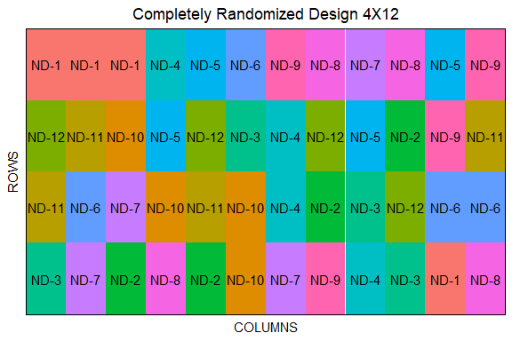

```r
plt <- plot(crd3)
```

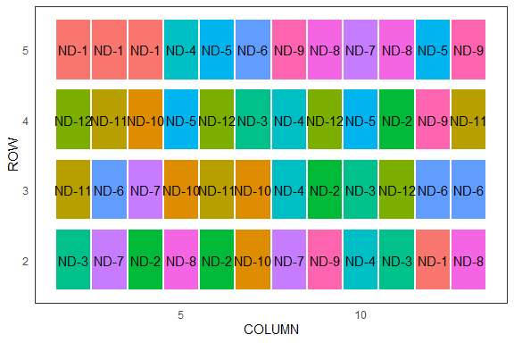

```r
p <- full_control_positions(plt$field_book, "COLUMN", "ROW", factor_name = "TREATMENT", label = "TREATMENT") + guides(fill = "none")
p
```

# Example 13: Sparse Allocation Design

```r
example("sparse_allocation")
```

[output not shown]

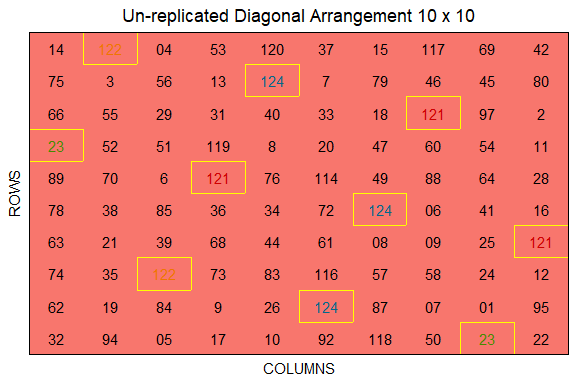

```r
plt <- plot(sparse)
```

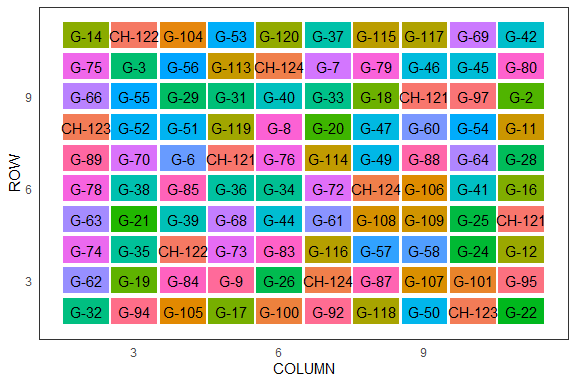

```r
p <- full_control_positions(plt$field_book[plt$field_book$LOCATION == "LOC1",], "COLUMN", "ROW", factor_name = "TREATMENT", label = "TREATMENT") + guides(fill = "none")
p
```

# Example 14: Row-Column Design

```r
example("row_column")
```

```
##
## rw_clm> # Example 1: Generates a row-column design with 3 full blocks and 36 treatments
## rw_clm> # and 6 rows. This for one location.
## rw_clm> rowcold1 <- row_column(t = 36, nrows = 6, r = 3, l = 1,
## rw_clm+                        plotNumber= 101,
## rw_clm+                        locationNames = "Loc1",
## rw_clm+                        seed = 21)
##
## rw_clm> rowcold1$infoDesign
## $rows
## [1] 6
##
## $columns
## [1] 6
##
## $reps
## [1] 3
##
## $treatments
## [1] 36
##
## $locations
## [1] 1
##
## $location_names
## [1] "Loc1"
##
## $seed
## [1] 21
##
## $id_design
## [1] 9
##
##
## rw_clm> rowcold1$resolvableBlocks
## $Loc_Loc1
## $Loc_Loc1$rep1
##      [,1] [,2] [,3] [,4] [,5] [,6]
## [1,]   18   34    9   13   28   11
## [2,]   17   15   29   21   30    1
```

[output cut: 117 more lines]

```
##
## rw_clm> head(rowcold2$fieldBook,12)
##    ID LOCATION PLOT REP ROW COLUMN ENTRY TREATMENT
## 1   1        1  101   1   1      1    28     ND-28
## 2   2        1  102   1   1      2     1      ND-1
## 3   3        1  103   1   1      3    21     ND-21
## 4   4        1  104   1   1      4     2      ND-2
## 5   5        1  105   1   1      5    30     ND-30
## 6   6        1  106   1   1      6    18     ND-18
## 7   7        1  107   1   2      1    16     ND-16
## 8   8        1  108   1   2      2    11     ND-11
## 9   9        1  109   1   2      3    24     ND-24
## 10 10        1  110   1   2      4    29     ND-29
## 11 11        1  111   1   2      5    19     ND-19
## 12 12        1  112   1   2      6    22     ND-22
```

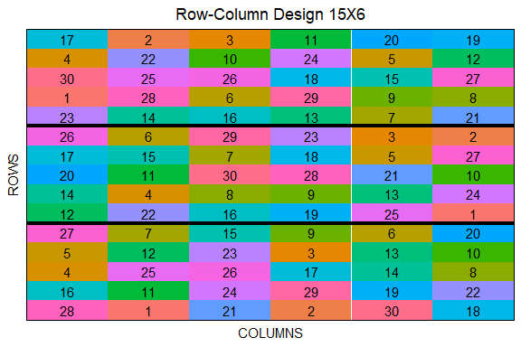

```r
plt <- plot(rowcold2, l = 1)
```

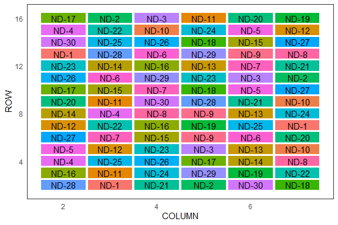

```r
p <- full_control_positions(plt$field_book[plt$field_book$LOCATION == "1",], "COLUMN", "ROW", factor_name = "TREATMENT", label = "TREATMENT") + guides(fill = "none")
p
```